# NYPD Shooting Incident Data Historic Final Project

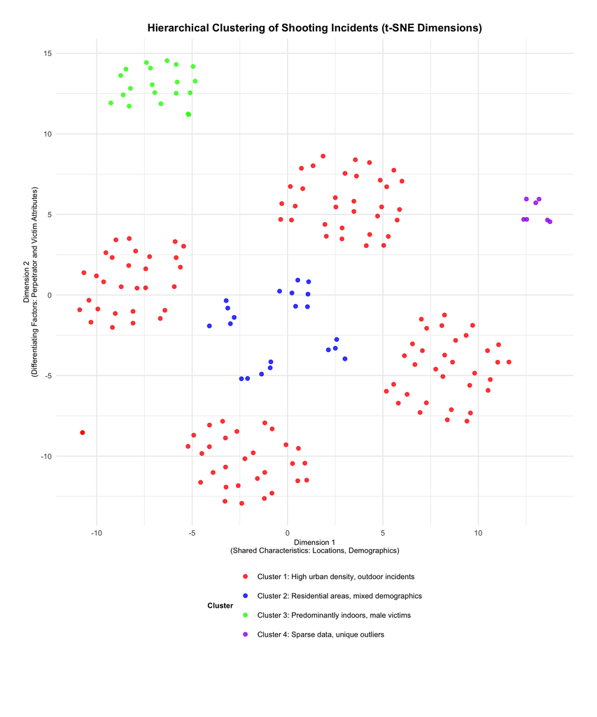

```r
# Plot clusters
ggplot(tsne_data, aes(x = X1, y = X2, color = Cluster)) +
  geom_point(alpha = 0.8, size = 2) +  # Slightly smaller points for better visibility
  labs(
    title = "Hierarchical Clustering of Shooting Incidents (t-SNE Dimensions)",
    x = "Dimension 1\n(Shared Characteristics: Locations, Demographics)",
    y = "Dimension 2\n(Differentiating Factors: Perpetrator and Victim Attributes)",
    color = "Cluster"
  ) +
  theme_minimal(base_size = 12) +  # Adjust base font size for readability
  scale_color_manual(
    values = c("red", "blue", "green", "purple"),
    labels = c(
      "Cluster 1: High urban density, outdoor incidents",
      "Cluster 2: Residential areas, mixed demographics",
      "Cluster 3: Predominantly indoors, male victims",
      "Cluster 4: Sparse data, unique outliers"
    )
  ) +
  theme(
    legend.position = "bottom",  # Move legend below the plot
    legend.title = element_text(size = 9, face = "bold"),
    legend.text = element_text(size = 9),
    legend.box = "vertical",  # Arrange legend items vertically
    plot.title = element_text(size = 13, face = "bold", hjust = 0.5),  # Center the title
    axis.title = element_text(size = 9),
    axis.text = element_text(size = 9),
    plot.margin = unit(c(1, 1, 3, 1), "cm")  # Add extra bottom margin for the vertical legend
  ) +
  guides(
    color = guide_legend(ncol = 1)  # Force legend into 1 column (vertical layout)
  )
```

4. Add at least two different visualizations & some analysis to your Rmd. Does this raise additional questions that you should investigate?
1. Additional questions:
- Why is the race unknown for some of these shootings?
- Where are the police officers concentrated?
- Could we place police officers in areas where shooting occur at a higher rate than other areas?
- Other visuals of the data mapping incidents by borough, time of day, and location type
- Relating the shooting incident to time of year, seasons, and holidays to determine if these are predictors of shooting incidents
2. This is a heat map of overlay of the New York City showing where the shootings occur.

```r
nypd_shooting_data_map <- nypd_shooting_data_tidy %>%
  filter(!is.na(Latitude), !is.na(Longitude))

leaflet(data = nypd_shooting_data_map) %>%
  addTiles() %>%  # Default OpenStreetMap layer
  setView(lng = -73.91, lat = 40.74, zoom = 11) %>%  # Center on NYC
  addHeatmap(
    lng = ~Longitude, lat = ~Latitude,
    intensity = ~1,  # Use 1 for uniform heat intensity
    blur = 20, max = 0.05, radius = 15  # Adjust heat map appearance
  ) %>%
  addLegend("bottomright", colors = c("blue", "red"), labels = c("Low", "High"),
            title = "Shooting Incident Density") %>%
  addProviderTiles(providers$OpenStreetMap)
```

[interactive chart not shown]

2. Forecasting using Random Forest technique with a heat map output

```r
# Step 1: Rename Columns if Necessary
nypd_shooting_data_tidy <- nypd_shooting_data_tidy %>%
  rename(
    latitude = Latitude,  # Adjust column names as needed
    longitude = Longitude
  )

# Step 2: Filter and Prepare Data for Modeling
nypd_shooting_data_clean <- nypd_shooting_data_tidy %>%
  filter(!is.na(latitude), !is.na(longitude)) %>%  # Remove rows with missing coordinates
  mutate(Shooting = as.factor(1))  # Add "Shooting" as a factor for modeling

# Step 3: Add Synthetic Non-Shooting Data
set.seed(123)
non_shooting_data <- data.frame(
  latitude = runif(nrow(nypd_shooting_data_clean), min = 40.5, max = 40.9),
  longitude = runif(nrow(nypd_shooting_data_clean), min = -74.2, max = -73.7),
  Shooting = as.factor(0)  # Non-shooting data labeled as 0
)

# Step 4: Combine Shooting and Non-Shooting Data
combined_data <- rbind(
  nypd_shooting_data_clean %>% select(latitude, longitude, Shooting),
  non_shooting_data
)

# Step 5: Train-Test Split
set.seed(123)
train_index <- sample(seq_len(nrow(combined_data)), size = 0.8 * nrow(combined_data))
train_data <- combined_data[train_index, ]
test_data <- combined_data[-train_index, ]

# Step 6: Train Random Forest Model
rf_model <- randomForest(
  Shooting ~ latitude + longitude,
  data = train_data,
  ntree = 500,
  mtry = 2,
  importance = TRUE
)

# Step 7: Generate Prediction Grid
latitude_seq <- seq(min(combined_data$latitude), max(combined_data$latitude), length.out = 100)
longitude_seq <- seq(min(combined_data$longitude), max(combined_data$longitude), length.out = 100)

grid_data <- expand.grid(
  latitude = latitude_seq,
  longitude = longitude_seq
)

# Predict probabilities on the grid
grid_data$Shooting_Probability <- predict(rf_model, grid_data, type = "prob")[, 2]

# Step 8: Filter Data Based on Custom Probability Thresholds
medium_threshold <- 0.6  # Customize thresholds as needed
filtered_data <- grid_data %>%
  filter(Shooting_Probability >= medium_threshold)  # Display medium or higher likelihood

# Step 9: Create Leaflet Heatmap
leaflet(filtered_data) %>%
  addTiles() %>%
  setView(lng = -73.91, lat = 40.74, zoom = 11) %>%  # Center on NYC
  addHeatmap(
    lng = ~longitude, lat = ~latitude,
    intensity = ~Shooting_Probability,  # Use predicted probabilities for heatmap intensity
    blur = 15,  # Moderate blur for smoother transitions
    max = 1,  # Maximum intensity value
    radius = 40,  # Large radius for noticeable points
    gradient = colorNumeric(
      palette = c("blue", "green", "yellow", "orange", "red"),  # Full gradient
      domain = c(0, 1)  # Full probability range
    )
  ) %>%
  addLegend(
    "bottomright",
    colors = c("blue", "green", "yellow", "orange", "red"),  # 5 colors
    labels = c("Low (0-0.4)", "Medium (0.4-0.6)", "High (0.6-0.8)", "Very High (0.8-1.0)", ""),  # 5 labels
    title = "Shooting Likelihood"
  )
```

[interactive chart not shown]

3. Race comparison of the victim and perpetrator.

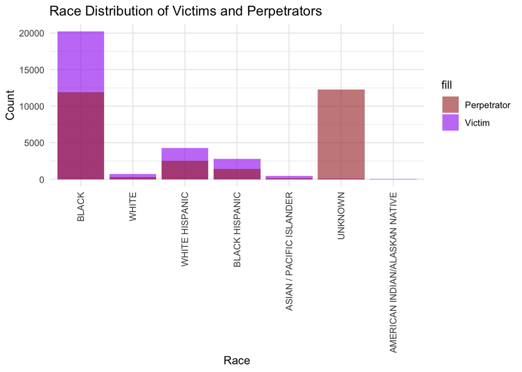

```r
ggplot(nypd_shooting_data_tidy) +
  geom_bar(aes(x = VIC_RACE, fill = "Victim"), alpha = 0.6, position = "dodge") +
  geom_bar(aes(x = PERP_RACE, fill = "Perpetrator"), alpha = 0.6, position = "dodge") +
  scale_fill_manual(values = c("Victim" = "purple", "Perpetrator" = "brown")) +
  labs(title = "Race Distribution of Victims and Perpetrators", x = "Race", y = "Count") +
  theme_minimal() +
   theme(axis.text.x = element_text(angle = 90, hjust = 1, vjust = 0.5))
```